# Data analysis report

Hamza Snoussi

2021-08-27

## Introduction

The data used in this report is the data scraped using the `FacebookScraping3.0` function combined with the data already existant in the website **Agrico.tn**

data source : **ملتقى الفلاحين و مربي الأبقار و الماشية بتونس**

## Dates Analysis

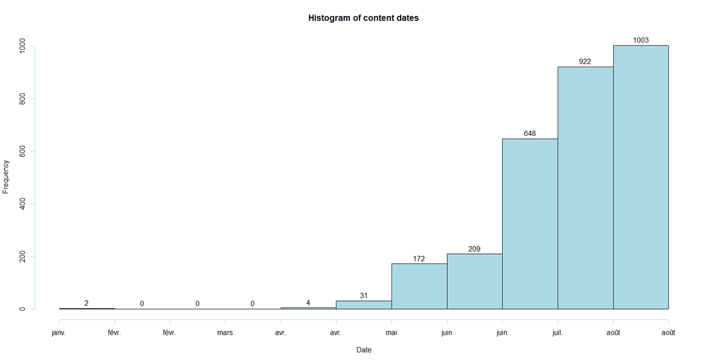

Histogram of dates of posts scraped

In this group we can see that July and August are the months where the community is posting the most, the inconvience is that we don't have data for the previous months (May,April ...) , and it will be too costy and irrelevant to go back to these months and scrape data.

Future analysis will determine the pattern and the seasonality if it exists.

## Content Analysis

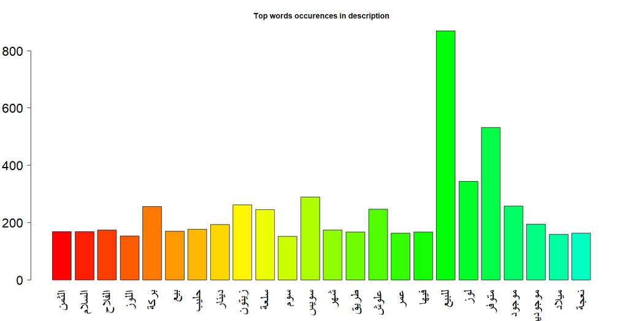

Top occurences in content

After combining all the existant content data available, and taking only the unique descriptions, and some words cleaning, these words represent the most occurent words in our data

each of theses words has been detected more than 150 time, some of them could be category or type indicators, like : **"للبيع"** **"متوفر"** etc...

## Cities Analysis

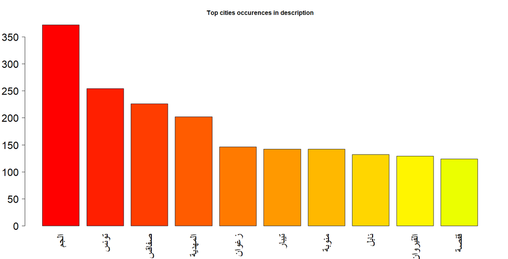

Top cities in content

These are the top cities mentioned in the descriptions of both newly scraped data and the website data.

## Posters

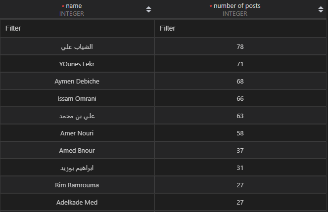

Top 10 posters

although all buyers and seller posters in facebook groups are potential Agrico users, theses 10 posters are the top 10 in number of post in the range : `from 2021-05-26 to 2021-08-25`